# Canadian figure skating champions

Guy Spurrier

2018-01-12

These four plots were prepared for publication with final day coverage of the 2018 Canadian figure skating championships. There were a few troubles with the data, as seen in the code notations below. The fixes aren’t particularly elegant, but they served their purposes.

(And yes, truth be told, this is a data-viz exercise that probably could be best solved with a table rather than a plot.)

Future learning will have to tackle more efficient solutions for dealing with:

— the misrepresented accented characters (as years are added, the hard-coded fixes to names will not be work because the row positions will have changed), — string replacements (see the Constance Wilson problem in the women’s section and the Gold-Silver-Bronze alphabetizing problem)

The biggest problem was with the plot titles. For readability, it’s best to use horizontal bar charts. Previous plotting exercises showed that `ggplot` attaches the plot titles, subtitles and captions to the data panel of the plot, not the entire area. As plots were prepared with longer names in the y axis, the plot title and subtitle became more obviously our of whack. Attempts to use `hjust` inside individual parameters of `theme()` proved to be unsatisfying. They also became unworkable when saving the plot from default to the desired 640px width.

```r
#code goes here
library(tidyverse)
```

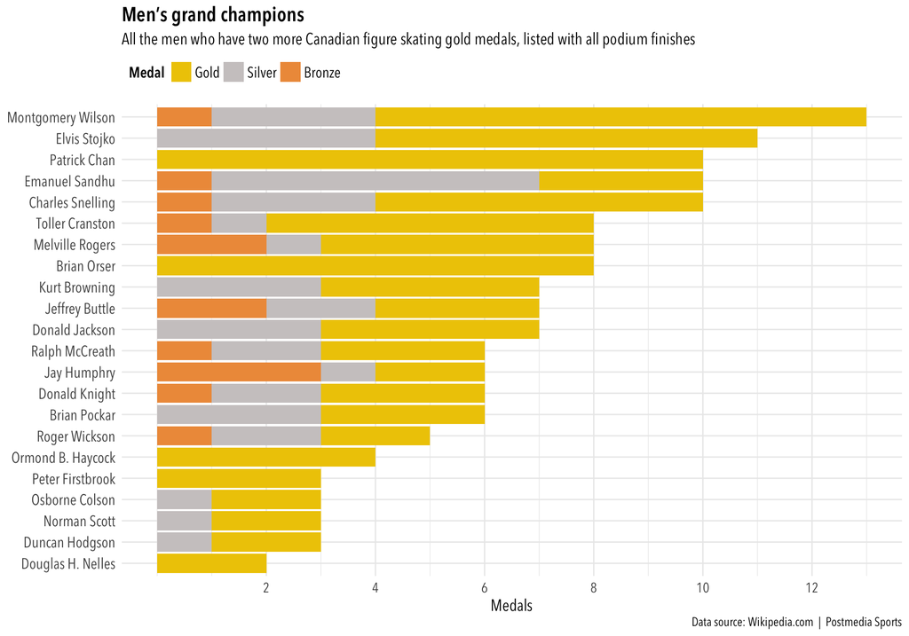

[figure not shown]

[figure not shown]

[figure not shown]

```r
library(cowplot)
library(RColorBrewer)
library(stringr)
library(janitor)
devtools::install_github("sfirke/janitor") # advanced github version with 2&3-level tabyls
fskt <- read_csv("~/Documents/R/Data files/Olympics/CdnFigureSkatingChampions.csv")
fskt$Category <- as.factor(fskt$Category)

#add 2018 medallists
fskt[186,4:6] <- c("Patrick Chan", "Keegan Messing", "Nam Nguyen")

#get counts for each colour of medal
menGold <- fskt %>% filter(Category == "Men's singles") %>% count(Gold) %>% arrange(desc(n))
menSilver <- fskt %>% filter(Category == "Men's singles") %>% count(Silver) %>% arrange(desc(n))
menBronze <- fskt %>% filter(Category == "Men's singles") %>% count(Bronze) %>% arrange(desc(n))

#fix the column names so the join below works properly
colnames(menGold) <- c("Skater", "Gold")
colnames(menSilver) <- c("Skater", "Silver")
colnames(menBronze) <- c("Skater", "Bronze")

#join the three tables — is there a way to join them all at once?
#dplyr documentation indicates you can only do two a time
menJoin <- full_join(menGold, menSilver)
menMedals <- full_join(menJoin, menBronze)
#remove the row that contains all the NA results (the years no competitions were held or not all medals were awarded)
menMedals <- slice(menMedals, -3)

#change all the remaining NA to 0, which is more accurate
menMedals[is.na(menMedals)] <- 0

#add medal totals for each skater
menMedals$Total <- menMedals$Gold + menMedals$Silver + menMedals$Bronze

#remove tibbles that are no longer needed
rm(menJoin, menGold, menSilver, menBronze)

subPlot <- menMedals %>% slice(1:22) #take all the men with 2+ gold medals

#gather menMedals into a plottable long tibble
plotMen <- gather(subPlot, key = Medal, value = Count, c(Gold, Silver, Bronze))
plotMen$Total <- NULL #remove unnecessary column

#fix the names with incorrect accented characters
#plotMen[c(54,139,224),1] <- "Jayson Dénommée"
#plotMen[c(33,118,203),1] <- "Sébastian Britten"

#change the medal string for alphabetical plotting purposes
flipThese <- plotMen$Medal
flipThese <- flipThese %>% str_replace_all(pattern = "Gold", replacement = "1.Gold")
flipThese <- flipThese %>% str_replace_all(pattern = "Silver", replacement = "2.Silver")
flipThese <- flipThese %>% str_replace_all(pattern = "Bronze", replacement = "3.Bronze")
plotMen$Medal <- flipThese
plotMen$Medal <- as.factor(plotMen$Medal)

quartzFonts(ANXTC = c("Avenir Next Condensed Regular", "Avenir Next Condensed Demi Bold", "Avenir Next Condensed Italic", "Avenir Next Condensed Demi Bold Italic"))

ggplot(plotMen) +
  geom_col(aes(x = reorder(Skater, +Count), y = Count, fill = Medal)) +
  coord_flip() +
  theme_minimal() +
  theme(text = element_text(family = "ANXTC"), plot.title = element_text(size = 16, face = "bold"), plot.subtitle = element_text(size = 13, face = "plain"), axis.title.x = element_text(size = 13, face = "plain"), axis.title.y = element_text(size = 13, face = "plain"), legend.title = element_text(size = 12, face = "bold"), legend.text = element_text(size = 12, face = "plain"), legend.direction = "horizontal", legend.position = "top", legend.justification = c(0,1), axis.text.x = element_text(size = 11, face = "plain"), axis.text.y = element_text(size = 12, face = "plain")) +
  labs(title = "Men’s grand champions", subtitle = "All the men who have two more Canadian figure skating gold medals, listed with all podium finishes", x = NULL, y = "Medals", caption = "Data source: Wikipedia.com  |  Postmedia Sports") +
  scale_y_continuous(breaks = c(2,4,6,8,10,12)) +
  scale_fill_manual(values = c("1.Gold" = "gold2", "2.Silver" = "snow3", "3.Bronze" = "tan2"), labels = c("Gold", "Silver", "Bronze"))
```